# ID5059 L03 - more basis functions

## Basis functions: piecewise constants

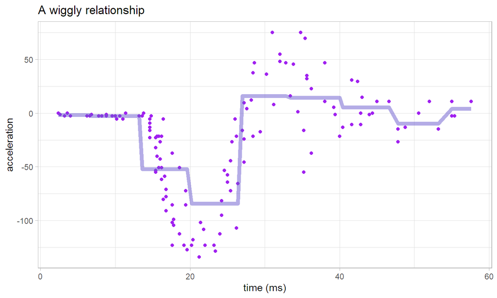

## A general local univariate basis

For calculation of a series of b-spline bases (\(B\)): \[ B_{i,j}(x)=\frac{x-\delta_{i}}{\delta_{i+j-1}-\delta_{i}} B_{i,j-1}(x)+\frac{\delta_{i+j}-x}{\delta_{i+j}-\delta_{i+1}}B_{i+1,j-1}(x) \label{eq:recurse} \]

Where we start with:

\[ B_{i,1}(x)= \begin{cases} 1& \delta_{i} \leq x \leq \delta_{i+1},\\ 0& \text{otherwise}. \end{cases} \label{eq:cases} \]

## Example b-spline basis

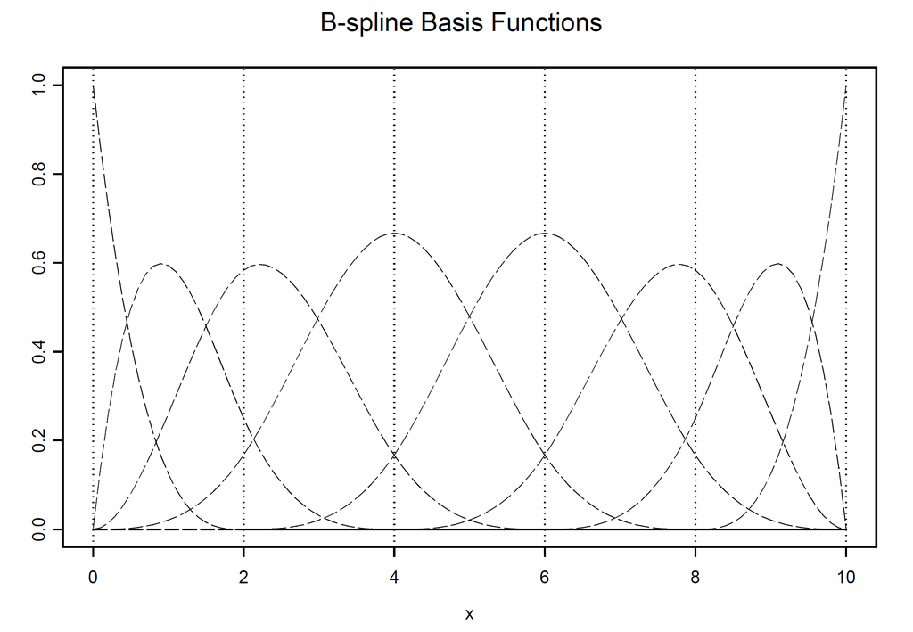

## Example b-spline basis

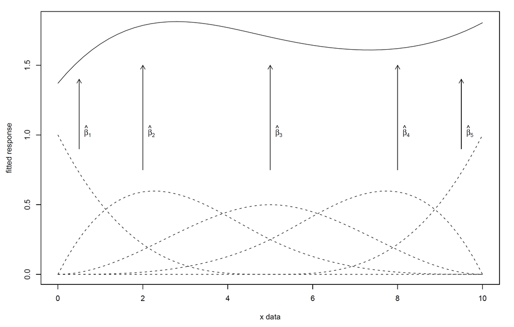

## B-splines

- B-splines are constructed to be zero outside some local region in \(x\)
- Calculations are relatively easy
- Curves can be as smooth as desired

## What about more dimensions?

- the result of multiplying a univariate basis function in one dimension against those of another
- results in a shape in higher dimensions
- two b-spline bases of degree 1 (linear) give tensor products that appear to be pyramids or ramps
- more curved bases such as \(3^{\rm rd}\) degree (cubic) b-spline bases will give bump-like tensor products

## Example b-spline basis

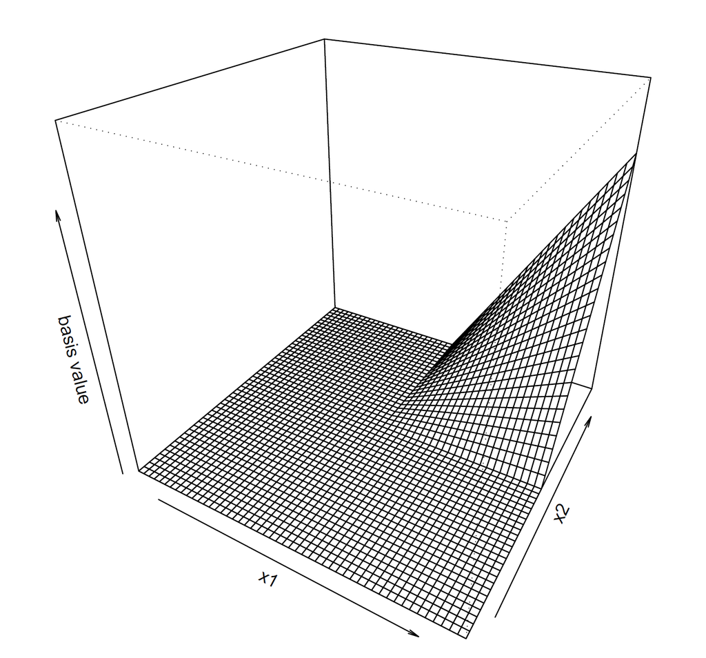

## Example b-spline basis

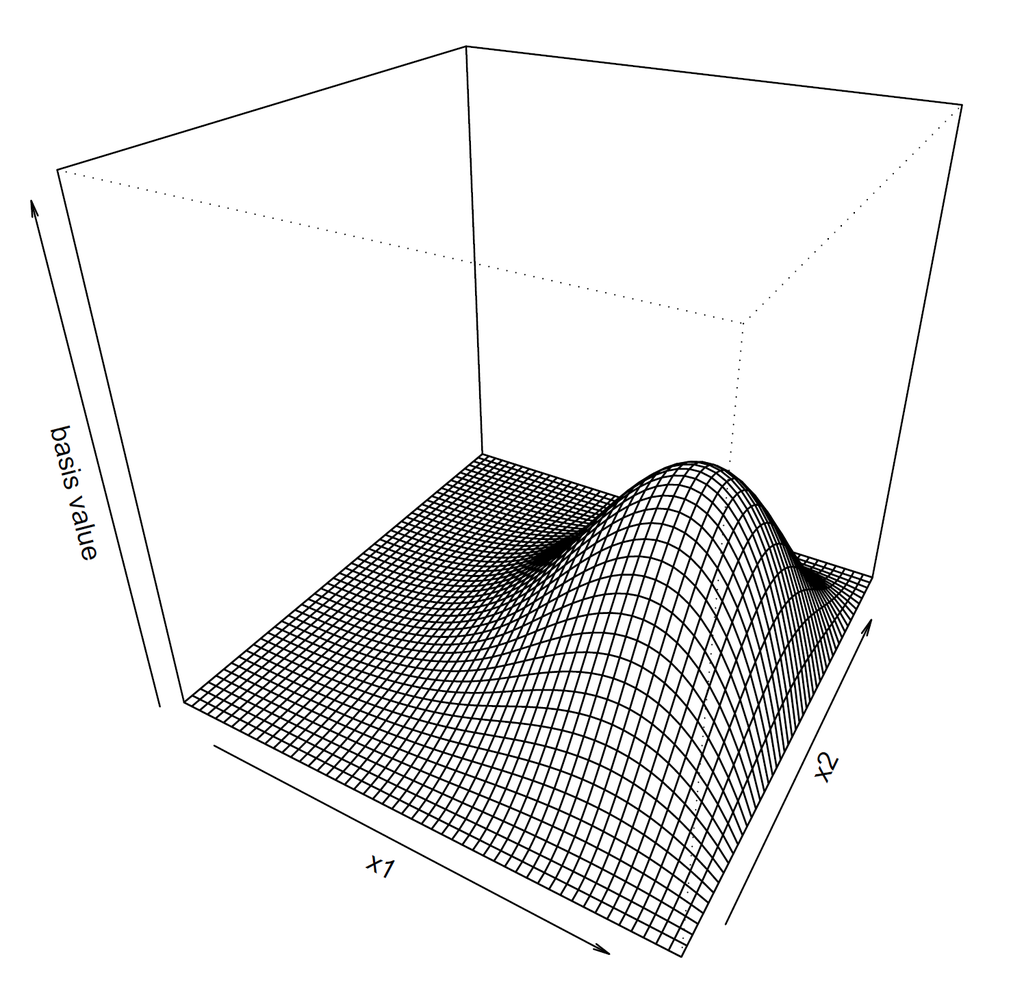

## Hyper-parameters

- For a particular \(f\), we estimate its parameters against the loss function
- May be other parameters which govern the complexity/form of \(f\): the *hyper-parameters* e.g. number of bases, band-width of a smoother, size of a neighborhood, learning rate of an NN, etc
- We minimise *generalisation error* to set these i.e. **model selection, rather than model fitting**
- This can be termed hyper-parameter *tuning*

## Simple hyper-parameter example

- Splines can have a parameter that governs complexity
- *Smoothing splines* have a smoothing parameter that balances fidelity to data to complexity of curve - a hyper-parameter that needs setting (tuning)

## Simpel hyper-parameter example

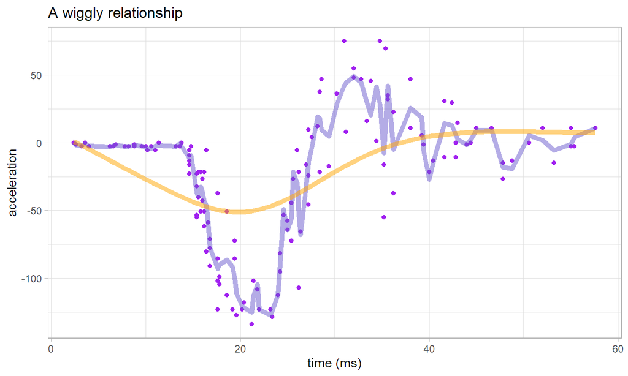

## Simple hyper-parameter example

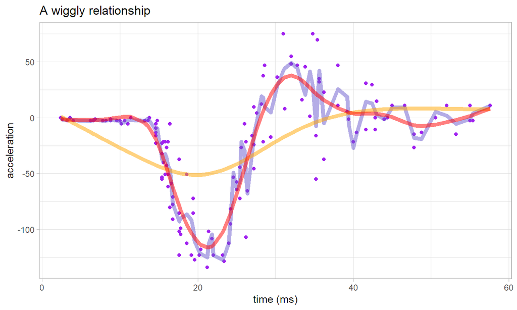

## Re-iterate

- *loss functions* for estimating model parameters given \(f\)
- *generalisation error* for model selection, hyper-parameter tuning

## Keywords and Reading

- **bootstrapping and OOB, hyper-parameter, hyper-parameter tuning**
- James *et al*: Section 7.1 - 7.4
- HT&F: Section 5.1, 5.7
- Geron: page 29-31

**Work through the associated L03 markdown document**